# Math 421 - Midterm

## Instruction

The midterm has two components: the Rmarkdown notebook (html) and the presentation. We will do the presentation in class. Post both the notebook and the presentation on your Github page.

**The notebook:** The notebook should be created using `rmarkdown` (like other assignments). The notebook should have a title. It should have a table of content (TOC form) or in a tab form. The Rmd files of Tab and Toc form are available on the class webpage.

**The Presentation:** Present your results in 5-10 minutes. To make the presentation using Rmarkdown, do the follows:

```
- In Rstudio -> File -> New File -> R markdown

- In the left panel, click to Presentation -> Click OK

- Now you have an Rmarkdown that can be knitted to be a html presentation
```

- You can also use Rmd samples of the class slides that are available on the class webpage.
- You do not need to rerun all the codes for the presentation. For example, to show the model comparison, you just need to show the image of the model comparison instead of running all the models again.
- To inset an image in a slide, use `![](image.png)`
- To scale images, you can follow these below instructions.
  - https://bookdown.org/yihui/rmarkdown-cookbook/figure-size.html
  - http://zevross.com/blog/2017/06/19/tips-and-tricks-for-working-with-images-and-figures-in-r-markdown-documents/
- To turn off message and warning of a code cell, use: `{r, message=FALSE, warning=FALSE}` for the cell.

**What to present**:

- Present Part 2 - Visualization
- Present Question Question 4, 5 and 6 in Part 3.
- Present any errors/challenges you run into and how you fix/overcome them.

**Data:**

The data for the mid-term project is the Rhode Island Department of Health Hospital Discharge Data. Each row of the data presents a patient.

Link: https://drive.google.com/open?id=15QNBf6YYKocK2nNIfpKDer58kQnCPNZJ

## I. Data Wranggling

1. Download the data file `hdd0318cy.sas7bdat`.
2. Use `read_sas` in library `haven` to read the data.

```r
library(haven)
df <- read_sas('C:/Users/student/OneDrive - Bryant University/Documents/R/Math421/hdd0318cy.sas7bdat')
```

3. Filter the data to have only patients of the year 2018 (`yod=18`)

```r
library(tidyverse)
library(dplyr)
df <- df %>% filter(yod==18)
```

4. Select to work with only following variables:

```r
                      "yod", "payfix","pay_ub92","age",
                      "sex","raceethn","provider","moa",
                      "yoa","mod","admtype", "asource" ,
                      "preopday" ,"los", "service" , "icu","ccu",
                      "dispub92", "payer"  ,"drg","trandb",
                      "randbg","randbs","orr", "anes","seq",
                      "lab","dtest", "ther","blood","phar",
                      "other","patcon","bwght","total","tot" ,
                      "ecodub92","b_wt","pt_state","diag_adm","ancilar" ,
                      "campus","er_fee","er_chrg","er_mode","obs_chrg",
                      "obs_hour","psycchrg","nicu_day"
```

```r
df <- df %>% select(yod,payfix, pay_ub92, age, sex, raceethn, provider, moa, yoa, mod, admtype, asource, preopday, los, service, icu, ccu, dispub92, payer, drg, trandb, randbg, randbs, orr, anes, seq, lab, dtest, ther,blood,phar,other,patcon,bwght,total,tot,ecodub92,b_wt,pt_state,diag_adm,ancilar, campus,er_fee,er_chrg,er_mode,obs_chrg,obs_hour,psycchrg,nicu_day)
```

*Notice*: You may want to save the current data to your computer for easy access later. To save the data file use `write_csv(df, 'midterm.csv')`, for example.

```r
write_csv(df, 'midterm_csv')
```

5. What are variables that have missing values?

```r
colSums(is.na(df))
```

```
##      yod   payfix pay_ub92      age      sex raceethn provider      moa
##        0   131478        0        0        0        0        0        0
##      yoa      mod  admtype  asource preopday      los  service      icu
##        0        0        0        0    60486        0        0        0
##      ccu dispub92    payer      drg   trandb   randbg   randbs      orr
##        0        0        0        0        0        0        0        0
##     anes      seq      lab    dtest     ther    blood     phar    other
##        0        0        0        0        0        0        0        0
##   patcon    bwght    total      tot ecodub92     b_wt pt_state diag_adm
##        0        0        0        0        0        0        0        0
##  ancilar   campus   er_fee  er_chrg  er_mode obs_chrg obs_hour psycchrg
##        0        0        0        0        0        0    77343        0
## nicu_day
##   124090
```

6. Remove all variables with missing values.

```r
df <- df %>% select(-payfix, -preopday, -obs_hour, -nicu_day)
```

7. Refer to the data description in the file `HDD2015-18cy6-20-19.docx`, which variable recording the month of admission?, which variable recording the month of discharge?

```r
#Month of Admission - moa
#Month of Discharge - mod
```

8. Which month admitted the most number of patients? Which month admitted the most number of male patients?

```r
df %>%
  count(moa) %>%
  arrange(-n)
```

```
## # A tibble: 12 × 2
##      moa     n
##    <dbl> <int>
##  1    10 11408
##  2     5 11404
##  3     1 11309
##  4     8 11199
##  5     4 11174
##  6     3 11073
##  7     7 10962
##  8    12 10698
##  9     6 10690
## 10     9 10666
## 11    11 10636
## 12     2 10259
```

```r
#October admitted the most patients
df %>%
  filter(sex=='1') %>%
  count(moa) %>%
  arrange(-n)
```

```
## # A tibble: 12 × 2
##      moa     n
##    <dbl> <int>
##  1    10  5164
##  2     5  5066
##  3     8  5028
##  4     4  4989
##  5     3  4978
##  6     1  4970
##  7     7  4910
##  8    12  4855
##  9     6  4810
## 10    11  4800
## 11     9  4683
## 12     2  4546
```

```r
#October admitted most male patients
```

9. Which month has the most number of teenage female patients?

```r
df %>%
  filter(sex=='2', age>='13'& age<='19') %>%
  count(moa) %>%
  arrange(-n)
```

```
## # A tibble: 12 × 2
##      moa     n
##    <dbl> <int>
##  1     3   226
##  2     5   220
##  3    10   212
##  4    12   208
##  5     1   207
##  6     9   196
##  7     4   187
##  8    11   177
##  9     2   172
## 10     8   172
## 11     7   171
## 12     6   169
```

```r
#March has most teenage female patients
```

10. Which provider has the most number of female patients in October?

```r
df %>%
  filter(sex=='2', moa=='10') %>%
  count(provider) %>%
  arrange(-n)
```

```
## # A tibble: 12 × 2
##    provider     n
##    <chr>    <int>
##  1 7205      1517
##  2 7214      1224
##  3 7204       872
##  4 7210       699
##  5 7209       351
##  6 7206       333
##  7 7213       317
##  8 7201       294
##  9 7216       256
## 10 7202       212
## 11 7211       122
## 12 7215        46
```

```r
#provider 7205 has the most female patients in October
```

11. Are female patients older than male patients, on average?

```r
df %>%
  group_by(sex) %>%
  summarise(average_age = mean(age)) %>%
  arrange(-average_age)
```

```
## # A tibble: 3 × 2
##   sex   average_age
##   <chr>       <dbl>
## 1 1            51.5
## 2 2            50.9
## 3 9            43
```

```r
#Male patients are older on average
```

12. Calculate the average age of patients by months. Which month has the oldest patients on average age?

```r
df %>%
  group_by(moa) %>%
  summarise(average_age = mean(age)) %>%
  arrange(-average_age)
```

```
## # A tibble: 12 × 2
##      moa average_age
##    <dbl>       <dbl>
##  1     1        51.8
##  2     6        51.5
##  3    12        51.5
##  4     4        51.4
##  5     7        51.3
##  6     2        51.2
##  7     3        51.1
##  8    11        51.0
##  9     8        50.9
## 10    10        50.8
## 11     5        50.6
## 12     9        50.6
```

```r
#January has the oldest patients on average
```

13. What is the name of the provider that has the highest total charge?

```r
df %>%
  group_by(provider) %>%
  summarise(average_tot = mean(tot)) %>%
  arrange(-average_tot)
```

```
## # A tibble: 12 × 2
##    provider average_tot
##    <chr>          <dbl>
##  1 7215          69946.
##  2 7205          48739.
##  3 7213          38200.
##  4 7202          35504.
##  5 7204          35277.
##  6 7206          31018.
##  7 7210          27691.
##  8 7209          24539.
##  9 7211          24089.
## 10 7201          22775.
## 11 7214          22362.
## 12 7216          17782.
```

```r
#Provider 7215 has the highest total charge
```

14. What is the name of the provider that has the least total charge for teenage male on average?

```r
df %>%
  group_by(provider) %>%
  filter(sex=='1', age>='13'& age<='19') %>%
  summarise(average_tot = mean(tot)) %>%
  arrange(average_tot)
```

```
## # A tibble: 12 × 2
##    provider average_tot
##    <chr>          <dbl>
##  1 7206          10360.
##  2 7201          14434.
##  3 7210          18586.
##  4 7211          19742.
##  5 7213          22618.
##  6 7216          24060.
##  7 7204          24989.
##  8 7209          26573.
##  9 7214          28950
## 10 7202          29389.
## 11 7205          40215.
## 12 7215         100440.
```

```r
#Provider 7206 has the least charge for teenage males on average
```

15. Create a season (Spring, Summer, Fall, Winter) variable. Calculate the length of stays by season. Which season has the longest length of stays on average?

```r
df$season <- case_when(df$moa>=3 & df$moa < 6 ~ 'Spring', df$moa >= 6 & df$moa <9 ~'Summer', df$moa>= 9 & df$moa <12~  'Fall', TRUE ~ 'Winter')

df %>%
  group_by(season) %>%
  summarise(average_los = mean(los)) %>%
  arrange(-average_los)
```

```
## # A tibble: 4 × 2
##   season average_los
##   <chr>        <dbl>
## 1 Summer        4.96
## 2 Fall          4.96
## 3 Winter        4.93
## 4 Spring        4.84
```

```r
#Summer has the longest length of stays on average
```

16. On average, how much a 20 year-old male get charged for staying 1 day in the Fall season?

```r
df %>%
  filter(sex=='1', age=='20', season=='Fall', los=='1') %>%
  summarise(average_tot = mean(tot)) %>%
  arrange(average_tot)
```

```
## # A tibble: 1 × 1
##   average_tot
##         <dbl>
## 1       16511
```

```r
#16511
```

17. Write a paragraph to summarize the section and give your comments on the results. You could do some other calculations to support your points.

This section was focused on importing a dataset and lightly manipulating it in order to analyze it. I used a number of functions to count, arrange, summarize, and filter. Before analyzing the data, however, I had to filter only patients in 2018, and remove all variables with missing values. Some of my takeaways from this section are October had the most patients out of any month, summer had the longest length of stay on average, and January has the oldest patients on average. I also found it interesting that male patients are older on average, event though this is intuitively pleasing.

## II. Data Visualization

Continue with the data from part I.

1. Provides at least 10 meaningful plots. Comments on the plots. All plots should have title, caption, appropriate labels on x and y-axis

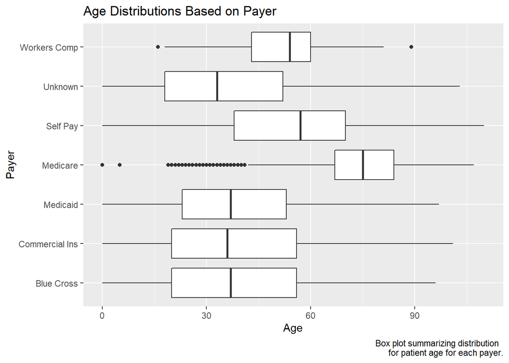

```r
library(tidyverse)
library(gganimate)
library(gifski)
library(dplyr)
library(knitr)
library(ggplot2)

df$sex <- case_when(
    df$sex==1 ~ 'Male',
    df$sex==2 ~ 'Female',
    TRUE ~ 'Unknown'
  )

df$raceethn <- case_when(
    df$raceethn==1 ~ 'White',
    df$raceethn==2 ~ 'Black',
    df$raceethn==3 ~ 'Asian',
    df$raceethn==4 ~ 'American Indian',
    df$raceethn==5 ~ 'Native Hawaiian',
    df$raceethn==6 ~ 'Other',
    df$raceethn==7 ~ 'Hispanic',
    TRUE ~ 'Unknown'
  )

df$admtype <- case_when(
    df$admtype==1 ~ 'Emergency',
    df$admtype==2 ~ 'Urgent',
    df$admtype==3 ~ 'Electric',
    df$admtype==4 ~ 'Newborn',
    df$admtype==5 ~ 'Court Committal',
    TRUE ~ 'Unknown'
  )

df$payer <- case_when(
    df$payer==0 ~ 'Medicare',
    df$payer==1 ~ 'Medicaid',
    df$payer==4 ~ 'Workers Comp',
    df$payer==5 ~ 'Blue Cross',
    df$payer==6 ~ 'Commercial Ins',
    df$payer==7 ~ 'Self Pay',
    TRUE ~ 'Unknown'
  )

df$dispub92 <- case_when(
    df$dispub92==01 ~ 'Self Care',
    df$dispub92==02 ~ 'Short Term Hosp',
    df$dispub92==03 ~ 'Nursing Fac',
    df$dispub92==04 ~ 'ICF',
    TRUE ~ 'Unknown'
)
df %>%
  ggplot()+
  geom_boxplot(mapping = aes(x = age, y = payer))+
  labs(x='Age',
       y='Payer',
       title='Age Distributions Based on Payer',
       caption='Box plot summarizing distribution
       for patient age for each payer.')
```

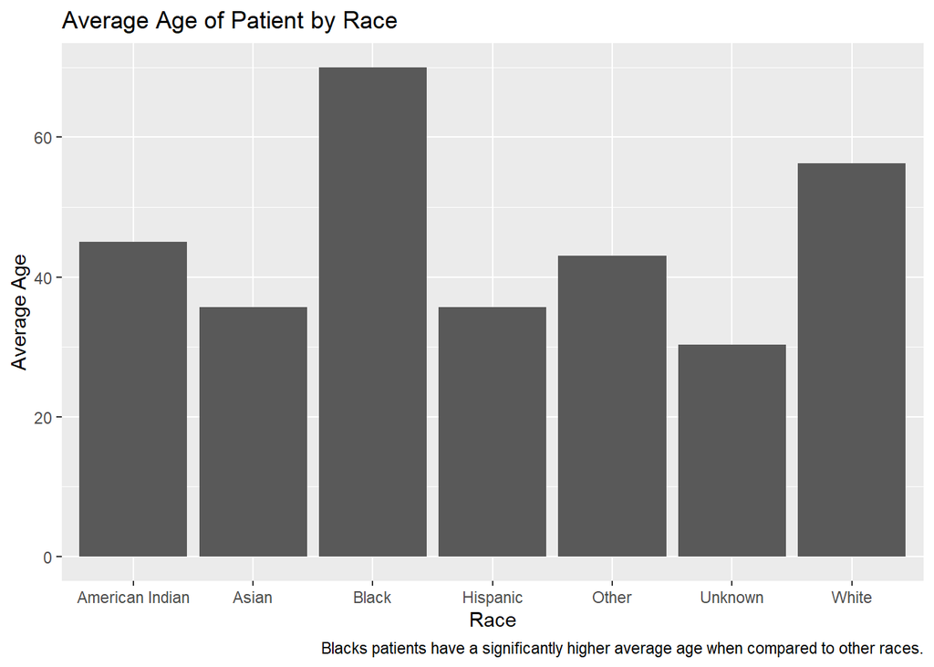

```r
df %>%
  group_by(raceethn, sex) %>%
  summarise(average_age=mean(age, na.rm=TRUE)) %>%
  ggplot()+
  geom_col(mapping=aes(x=raceethn,
                       y=average_age
                       ),
           position = 'dodge')+
  labs(x='Race',
       y = 'Average Age',

       title = 'Average Age of Patient by Race',
       caption = 'Blacks patients have a significantly higher average age when compared to other races.')
```

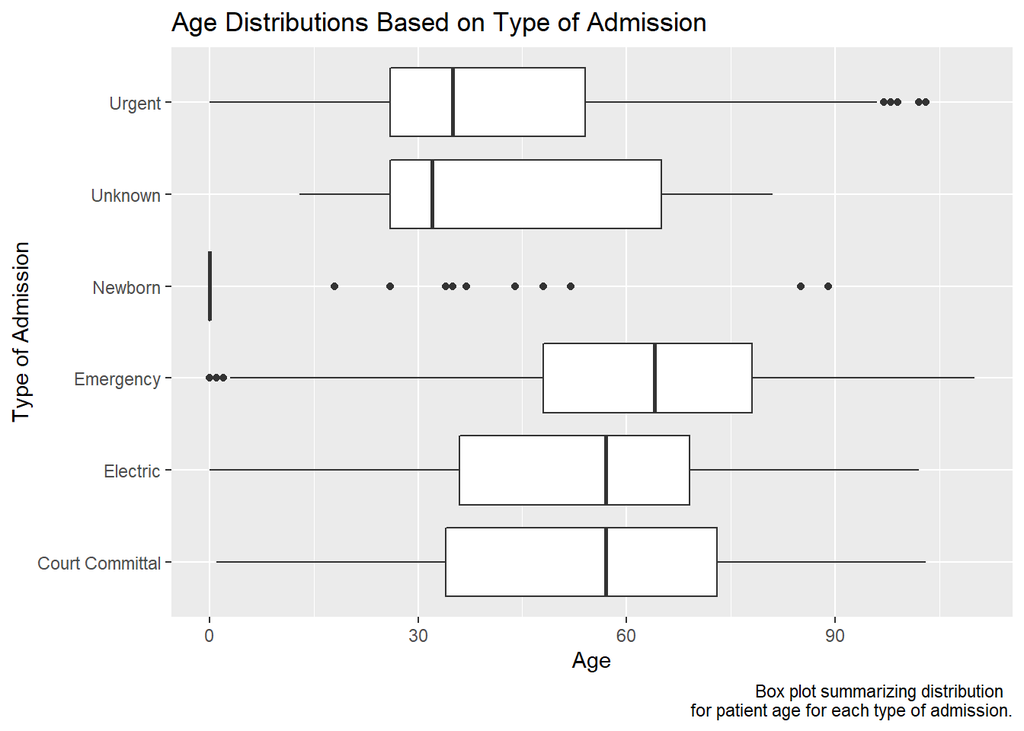

```r
df %>%
  ggplot()+
  geom_boxplot(mapping = aes(x = age, y = admtype))+
  labs(x='Age',
       y='Type of Admission',
       title='Age Distributions Based on Type of Admission',
       caption='Box plot summarizing distribution
       for patient age for each type of admission.')
```